# Week 4

Hao Ye

February 02, 2017

# 1 Objectives

- Changing colors in ggplot
- The theme layer in ggplot
- Custom color palettes (`viridis`, `spaceMovie`)
- Adding statistical transformations and summaries to plots

# 2 Review of ggplot

Previously, we introduced ggplot as a framework for constructing plots that emphasizes flexibility through its "grammar of graphics" system. Here we review some of the basic ideas.

## 2.1 Load the dataset from last week

```r
dat <- read.csv("../week-3/EconomistData.csv") # note the path
head(dat)
```

```
##   X     Country HDI.Rank   HDI CPI            Region
## 1 1 Afghanistan      172 0.398 1.5      Asia Pacific
## 2 2     Albania       70 0.739 3.1 East EU Cemt Asia
## 3 3     Algeria       96 0.698 2.9              MENA
## 4 4      Angola      148 0.486 2.0               SSA
## 5 5   Argentina       45 0.797 3.0          Americas
## 6 6     Armenia       86 0.716 2.6 East EU Cemt Asia
```

## 2.2 Scatter plot with CPI on the x axis and HDI on the y axis

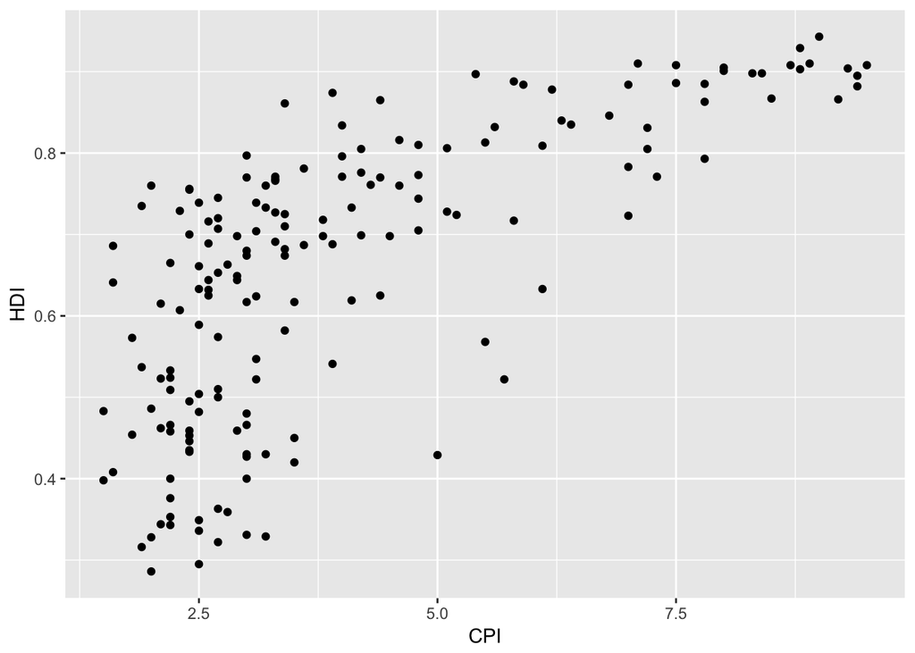

```r
library(ggplot2)
my_plot <- ggplot(dat, aes(x = CPI, y = HDI))
my_plot + geom_point()
```

# 3 Changing colors in ggplot

## 3.1 Intro

If we wanted to change the color of points in the plot, we might imagine two ways: 1. specify color in the geom layer (`geom_point` function) 2. specify color in the mapping layer (`aes` function)

What do you suppose each one does?

```r
my_plot <- ggplot(dat, aes(x = CPI, y = HDI, color = "blue"))
my_plot + geom_point()
```

```r
my_plot <- ggplot(dat, aes(x = CPI, y = HDI))
my_plot + geom_point(color = "blue")
```

## 3.2 Basic Color Specification

Setting the color to be defined by the region variable produces a colored boxplot:

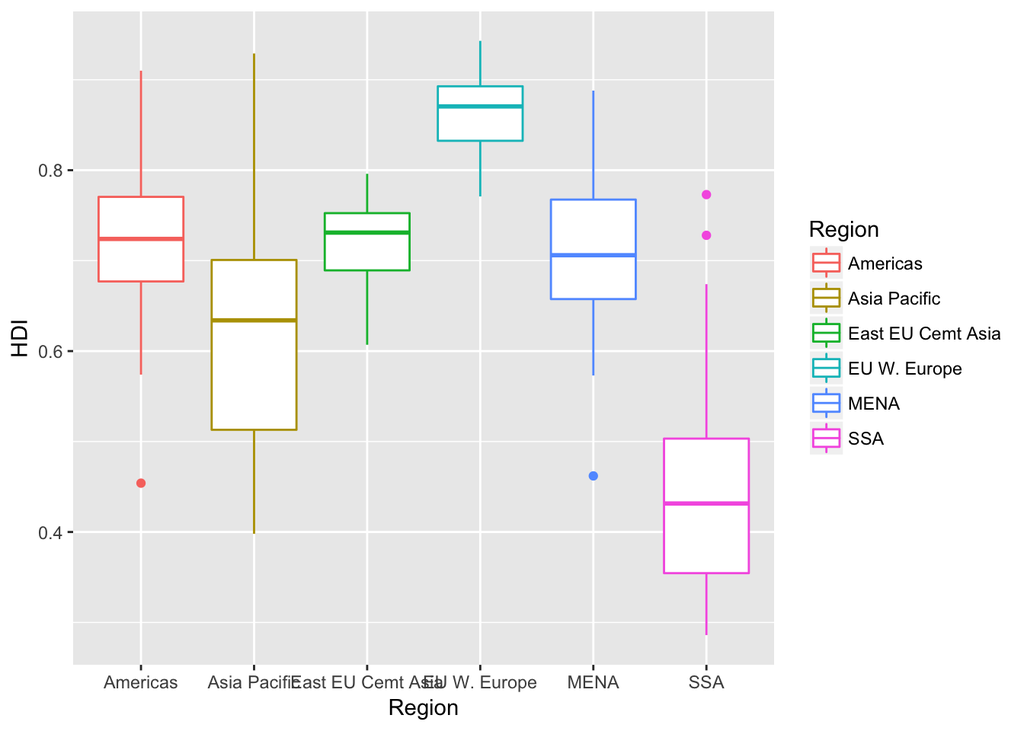

```r
my_plot <- ggplot(dat, aes(x = Region, y = HDI, color = Region))
my_plot + geom_boxplot()
```

But if we wanted to change the actual colors used, we need to specify what colors we want:

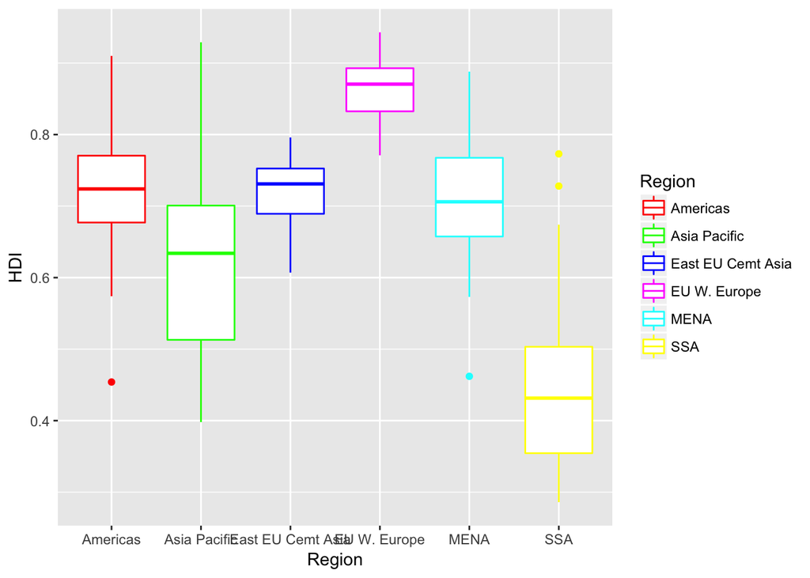

```r
my_plot <- ggplot(dat, aes(x = Region, y = HDI, color = Region))
my_plot + geom_boxplot() + scale_color_manual(values = c("red", "green", "blue", "magenta", "cyan", "yellow"))
```

And we can similarly define the exact mapping we want:

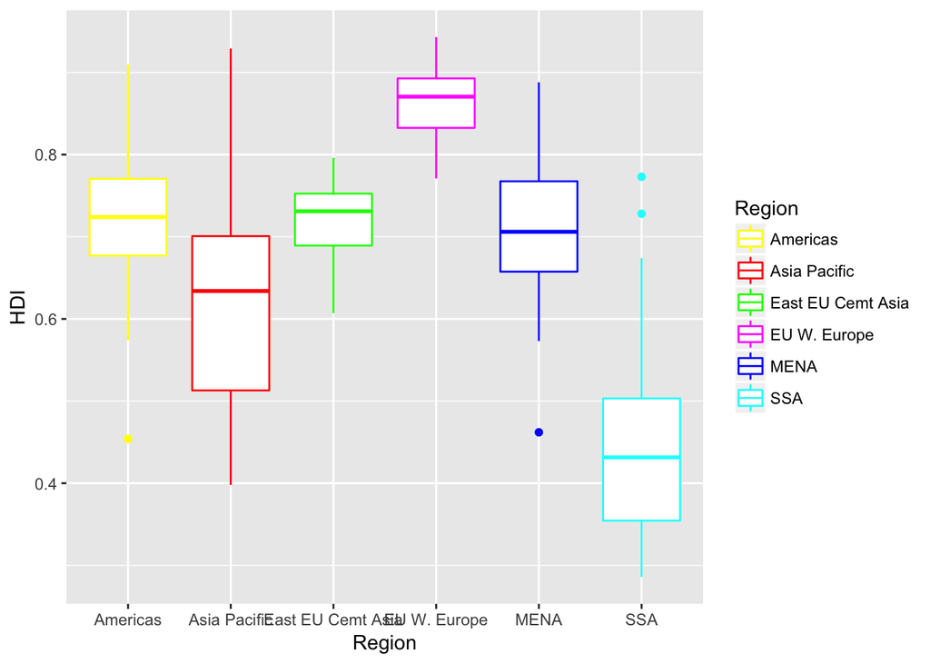

```r
my_plot <- ggplot(dat, aes(x = Region, y = HDI, color = Region))
my_plot + geom_boxplot() +
    scale_color_manual(values = c("Asia Pacific" = "red",
                                  "East EU Cemt Asia" = "green",
                                  "MENA" = "blue",
                                  "EU W. Europe" = "magenta",
                                  "SSA" = "cyan",
                                  "Americas" = "yellow"))
```

## 3.3 What are the colors?

Colors in R can be found using the names listed in the output of "colors":

```r
head(colors())
```

```
## [1] "white"         "aliceblue"     "antiquewhite"  "antiquewhite1"
## [5] "antiquewhite2" "antiquewhite3"
```

And we can use these names when specifying colors:

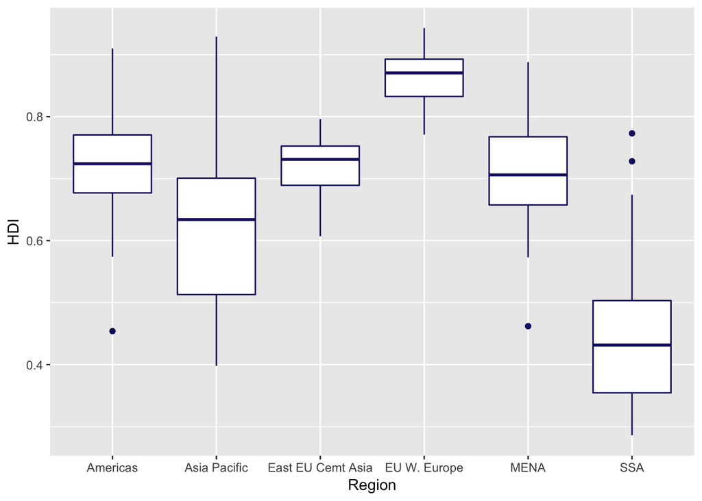

```r
my_plot <- ggplot(dat, aes(x = Region, y = HDI))
my_plot + geom_boxplot(color = "midnightblue")
```

Alternatively, we can use one of the standard color spaces:

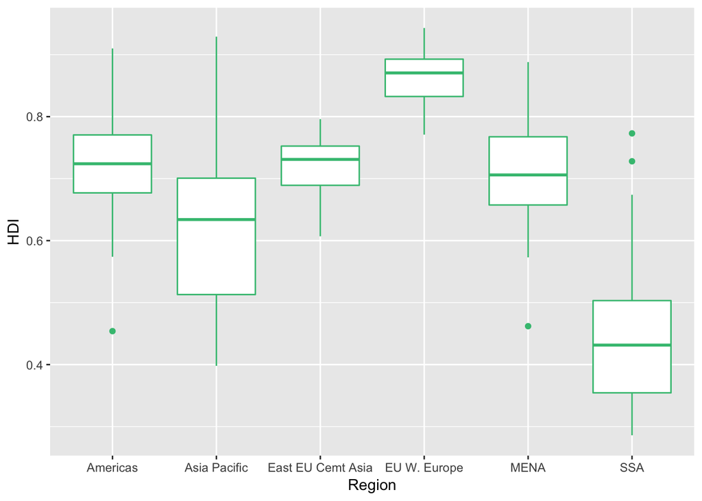

```r
my_color <- hsv(0.5, 0.75, 1.0) # <hue, saturation, value> color space
my_color <- rgb(0.25, 0.75, 0.5) # <red, green, blue> color space
my_color <- "#40C080" # using hexadecimal code
my_plot <- ggplot(dat, aes(x = Region, y = HDI))
my_plot + geom_boxplot(color = my_color)
```

# 4 The theme layer in ggplot

In ggplot, the `theme` layer controls all the **non-data** aspects of a plot.

## 4.1 Default themes

We can modify our plots by using some of the built-in themes:

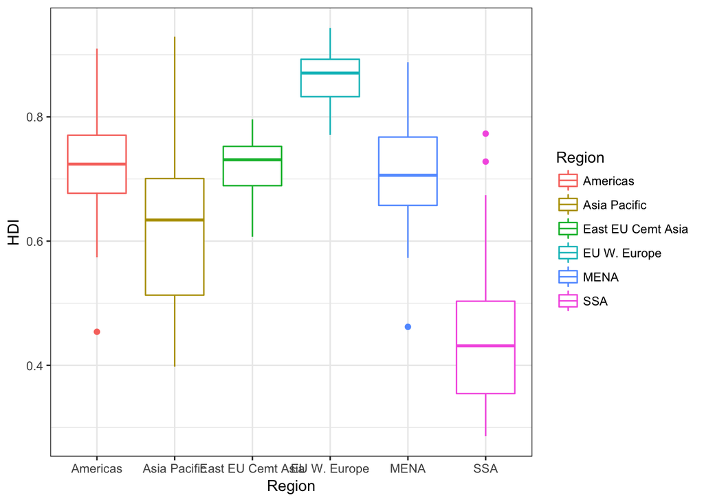

```r
my_plot <- ggplot(dat, aes(x = Region, y = HDI, color = Region)) + geom_boxplot()
my_plot + theme_bw()
```

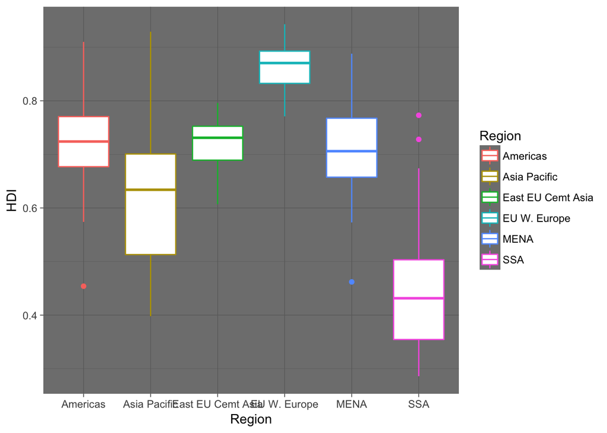

```r
my_plot + theme_dark()
```

## 4.2 Custom themes

We can also customize the theme and specify changes to various components of the plot:

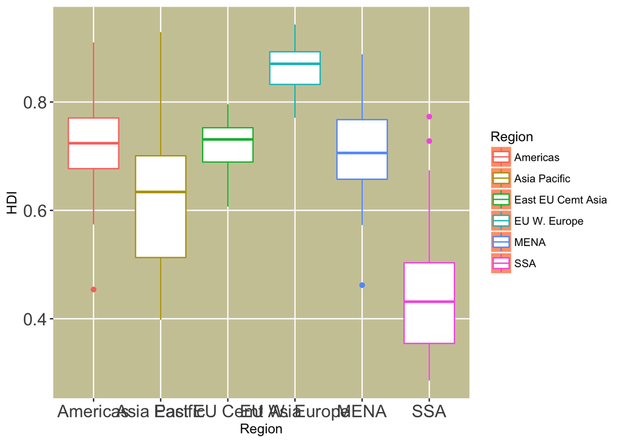

```r
my_plot + theme(
    axis.text = element_text(size = 14),
    legend.key = element_rect(fill = "lightsalmon"),
    legend.background = element_blank(),
    panel.grid.minor = element_blank(),
    panel.background = element_rect(fill = "lemonchiffon3")
)
```

Note that the modular nature of ggplot means you can save theme objects and re-use them, e.g. throughout a paper, or as part of a package, just like the default `theme_bw()`:

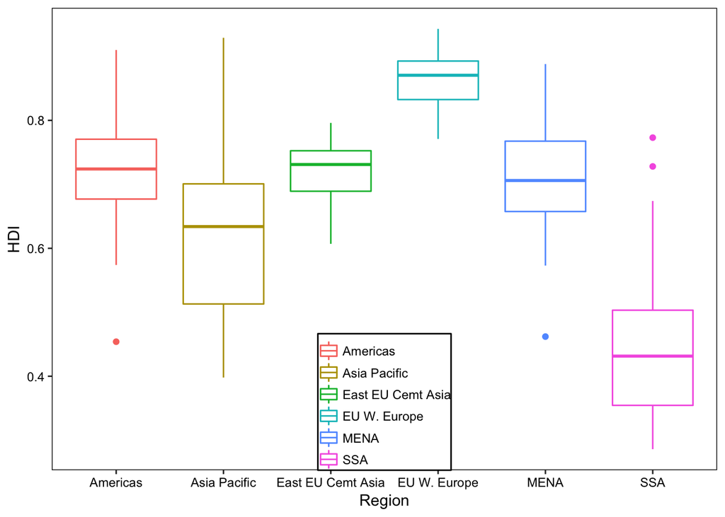

```r
my_theme <- theme(panel.grid.major = element_blank(),
                  panel.grid.minor = element_blank(),
                  axis.text = element_text(color = "black"),
                  legend.background = element_rect(color = "black"),
                  legend.key = element_blank(),
                  legend.title = element_blank(),
                  legend.position = c(0.5, 0),
                  legend.justification = c(0.5, 0),
                  legend.margin = margin(0.0, unit = "cm"),
                  legend.key.size = unit(1.05, "lines"),
                  legend.key.height = unit(1.05, "lines"),
                  panel.background = element_rect(color = "black", fill = NA))

my_plot + my_theme
```

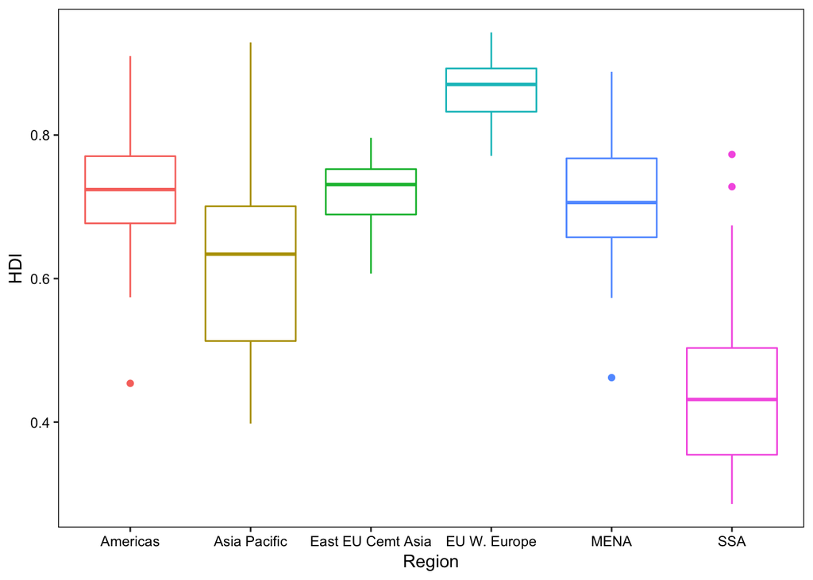

```r
my_plot + my_theme + theme(legend.position = "none")
```

# 5 Custom color palettes

Note that we previously specified a set of colors using `scale_color_manual` which is used to create a custom color scale (each color is manually specified.

## 5.1 Built-in color palettes

As you might expect, ggplot has some built-in color options. Here are some of the ones to generate a **discrete** set of colors:

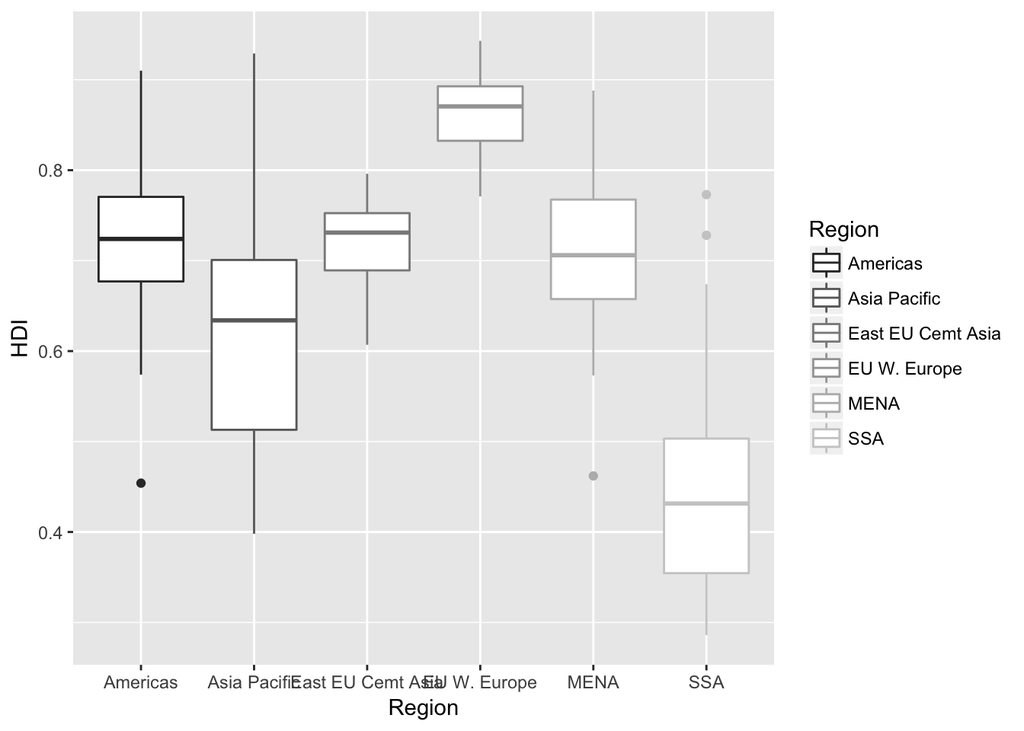

```r
my_plot + scale_color_grey()
```

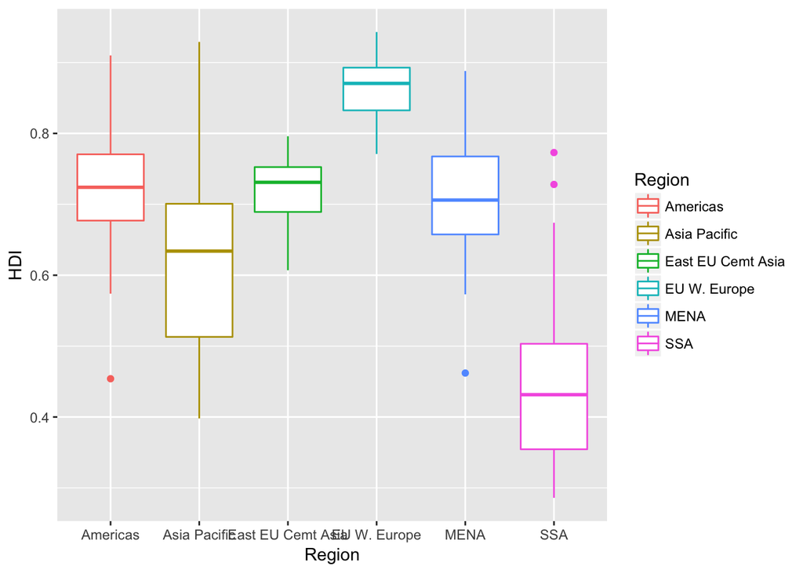

```r
my_plot + scale_color_hue()
```

And some to generate a **continuous** set of colors:

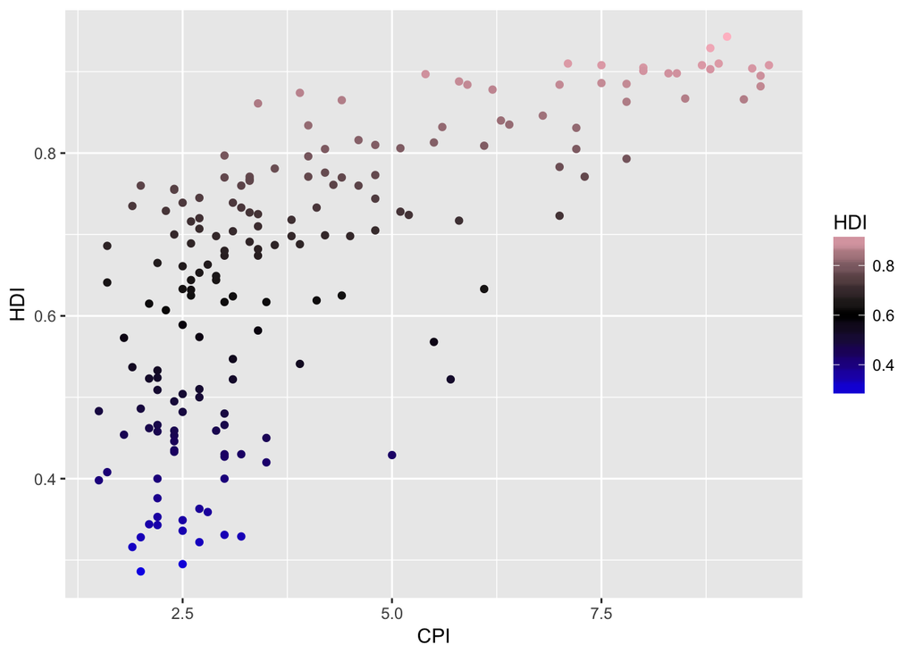

```r
my_plot_2 <- ggplot(dat, aes(x = CPI, y = HDI, color = HDI)) +
    geom_point()
my_plot_2 + scale_color_gradient2(low = "blue", mid = "black", high = "pink", midpoint = 0.6)
```

## 5.2 Color palettes from packages

We can also use color palettes provided in packages:

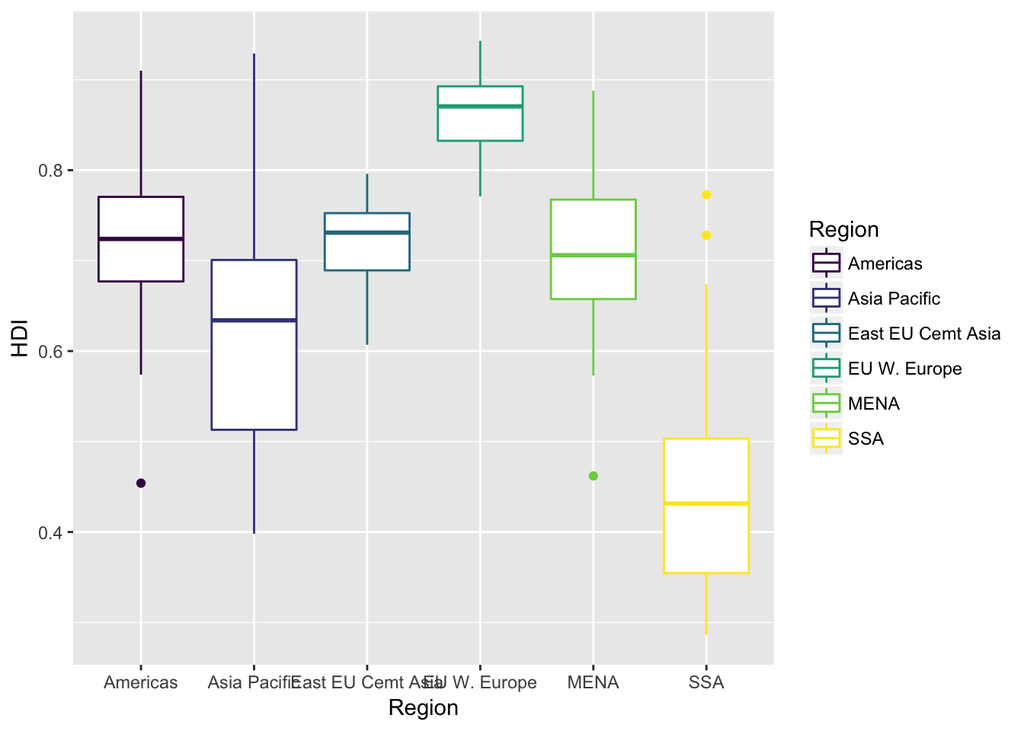

```r
library(viridis)
my_plot + scale_color_viridis(discrete = TRUE)
```

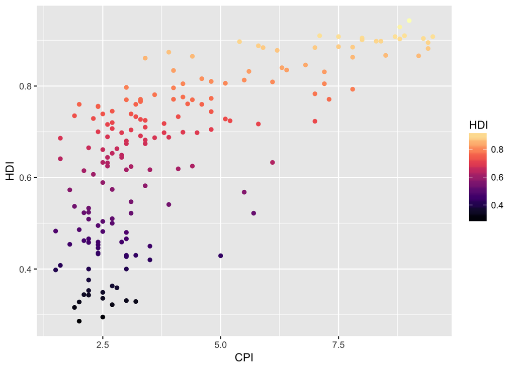

```r
my_plot_2 + scale_color_viridis(option = "A")
```

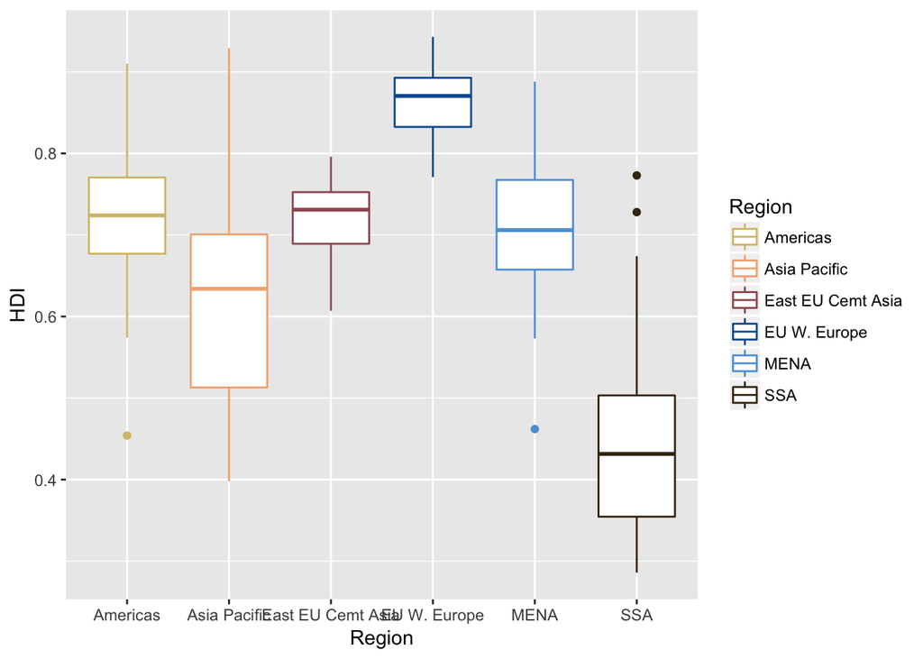

```r
library(spaceMovie)
my_plot + scale_color_manual(values = SW_palette("ANH"))
```

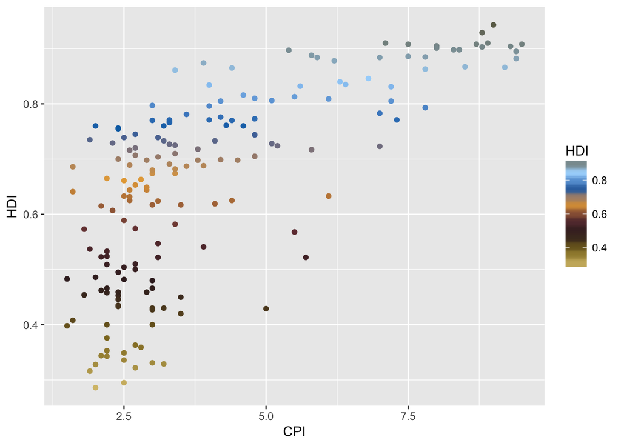

```r
my_plot_2 + scale_color_gradientn(colors = SW_palette("AOTC"))
```

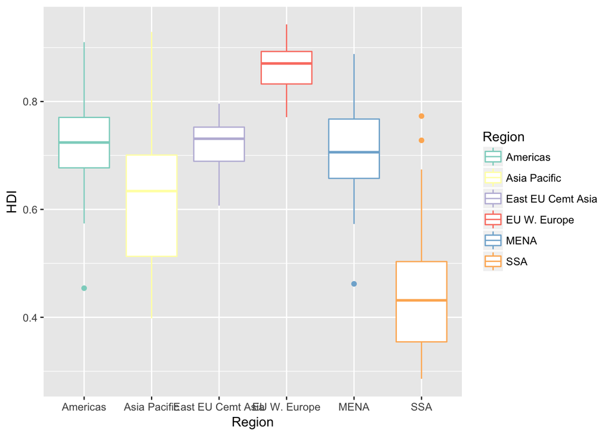

```r
my_plot + scale_color_brewer(palette = "Set3")
```

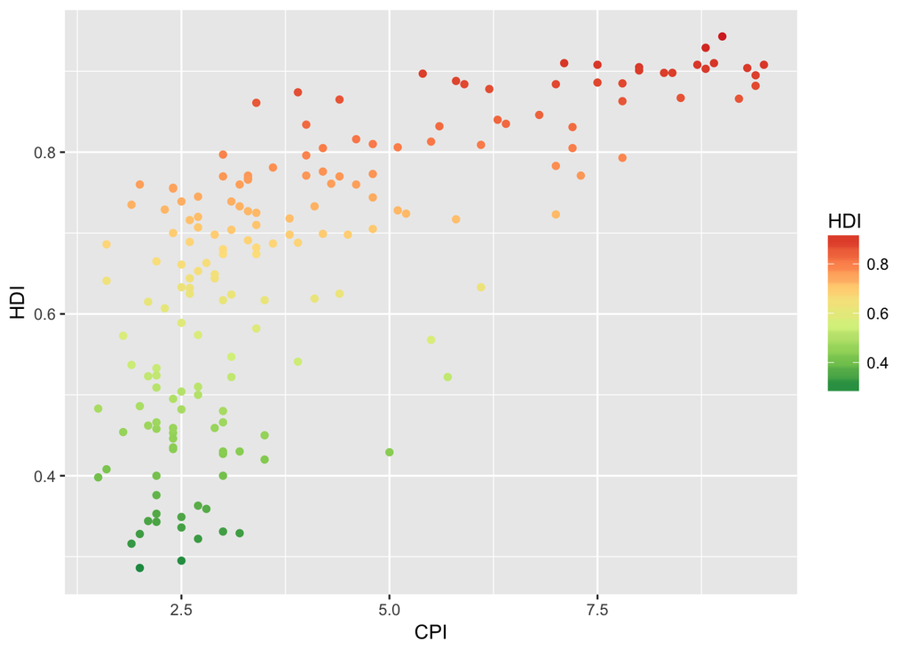

```r
my_plot_2 + scale_color_distiller(palette = "RdYlGn")
```

## 5.3 Exercises

1. Modify the HDI vs. CPI plot to use a different color and symbol for each region.

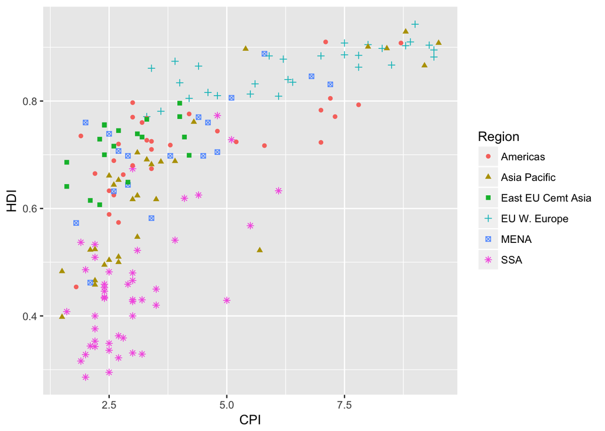

```r
ggplot(dat, aes(x = CPI, y = HDI,
                color = Region, shape = Region)) + geom_point()
```

2. Modify the HDI boxplot to use a different color palette for the lines and for the fill.

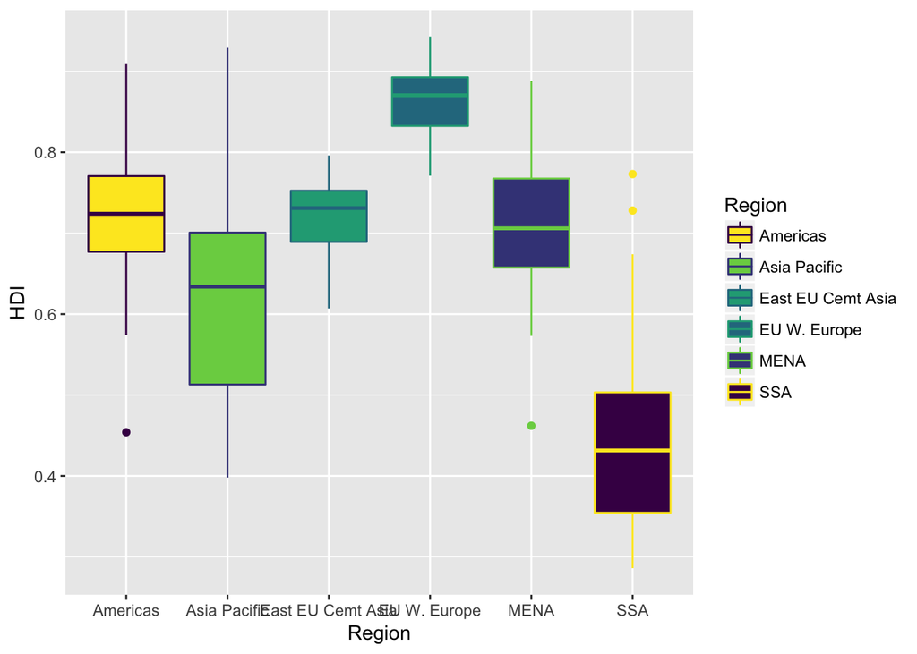

```r
ggplot(dat, aes(x = Region, y = HDI,
                color = Region, fill = Region)) +
    geom_boxplot() +
    scale_color_viridis(discrete = TRUE) +
    scale_fill_viridis(discrete = TRUE, direction = -1)
```

# 6 Adding statistic transformations and summaries to plots

By default, each `geom` has a `stat` component associated with it that describes how visually displays the plot. In `geom_point` for example, the `stat` is `identity`, because the x- and y- coordinates are being plotted as-is. In contrast, `geom_boxplot` must compute the bounds of the boxplot for the specified groups, and so that `stat` is `boxplot`.

For `geom_histogram`, the default `stat` is to count up the number of values in each bin:

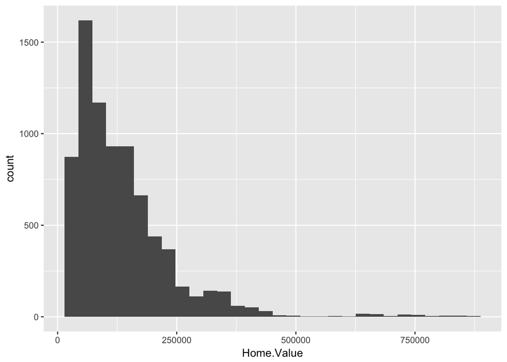

```r
housing <- read.csv("../week-3/landdata-states.csv")
ggplot(housing, aes(x = Home.Value)) +
    geom_histogram()
```

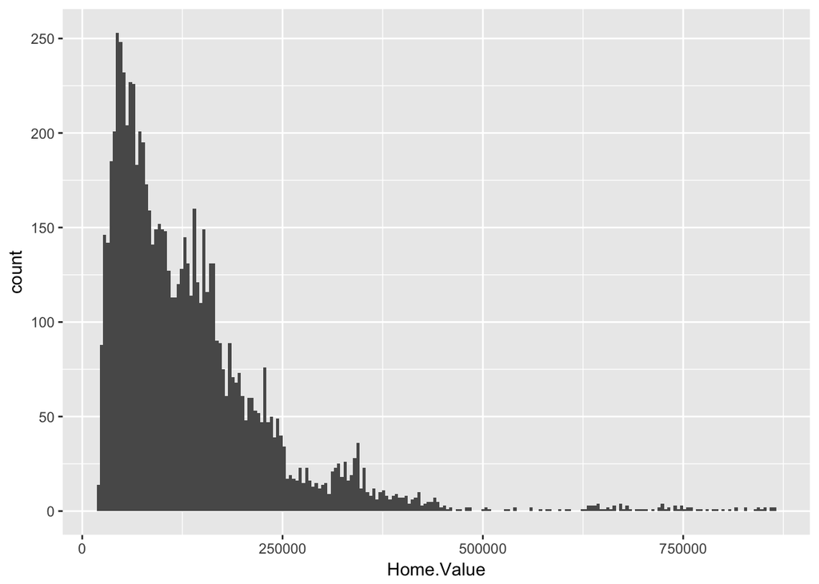

```r
ggplot(housing, aes(x = Home.Value)) +
    geom_histogram(stat = "bin", binwidth = 4000)
```

We can also add some of these statistical summaries to plots using `stat_*` functions instead of `geom_*` functions:

```
## No summary function supplied, defaulting to `mean_se()
## No summary function supplied, defaulting to `mean_se()
## No summary function supplied, defaulting to `mean_se()
## No summary function supplied, defaulting to `mean_se()
## No summary function supplied, defaulting to `mean_se()
## No summary function supplied, defaulting to `mean_se()
```

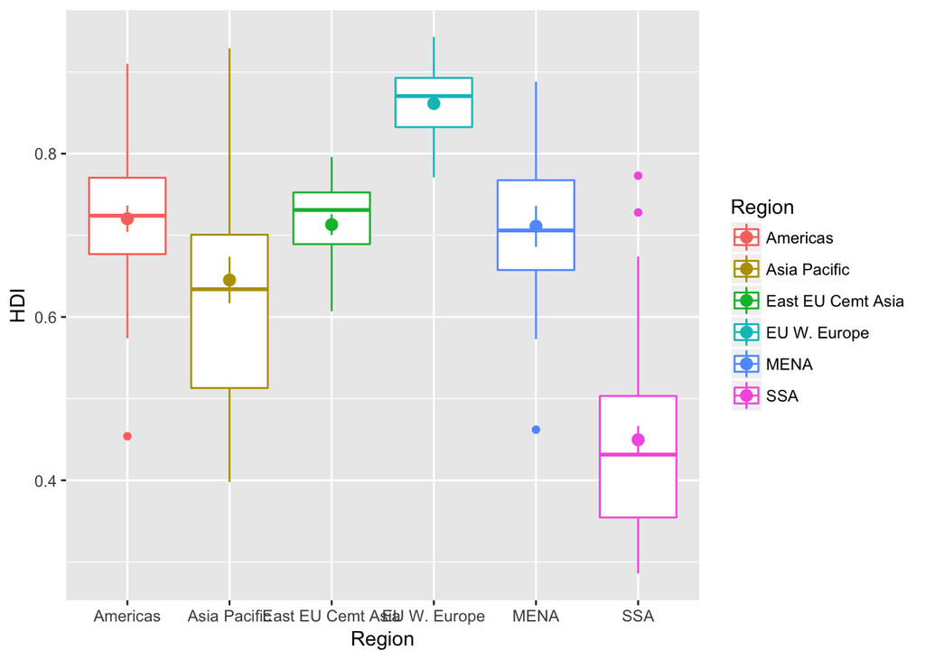

```r
my_plot + stat_summary_bin()
```

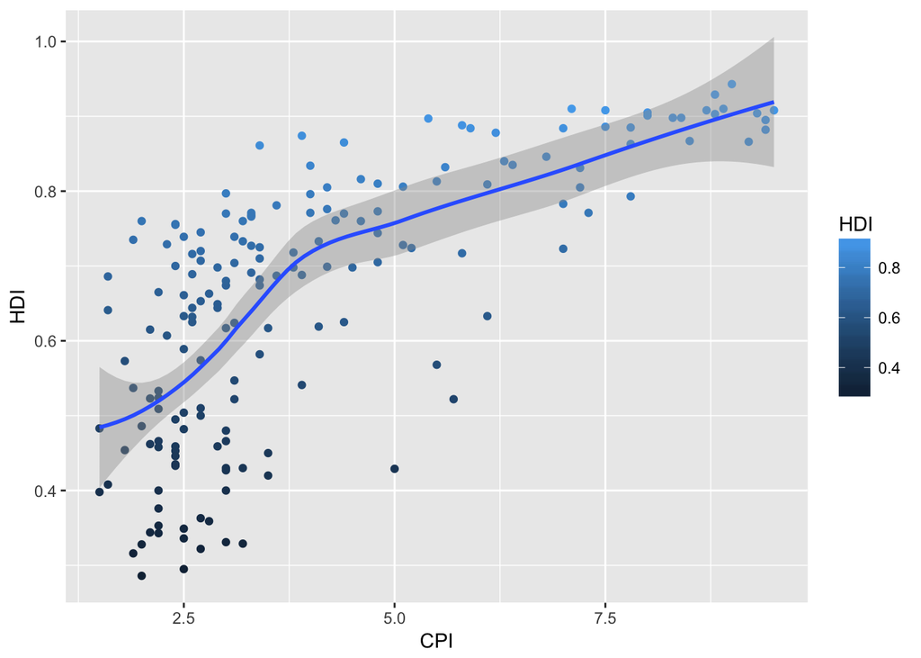

```r
my_plot_2 + stat_smooth()
```

## 6.1 Exercises

1. Overlay a smoothing line on top of the scatter plot of HDI vs. CPI using `geom_smooth`, but use a linear model for the predictions. Hint: see `?stat_smooth`.

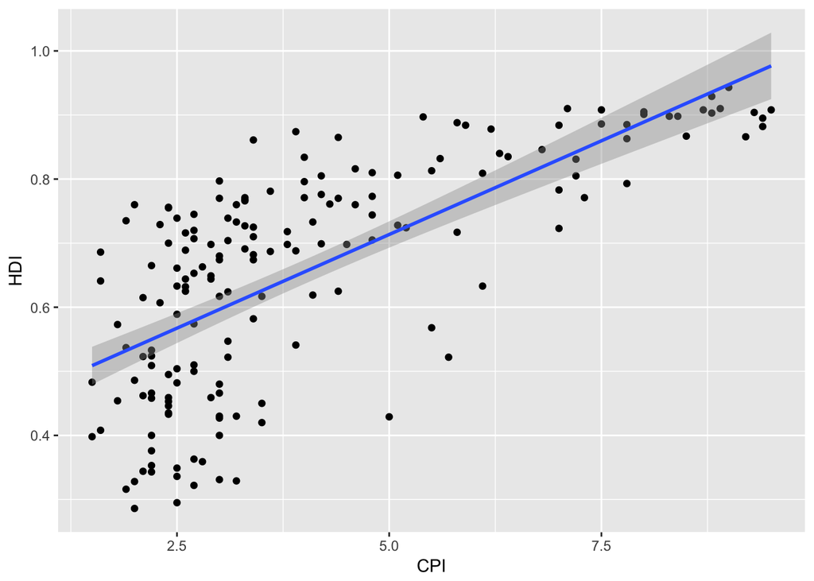

```r
ggplot(dat, aes(x = CPI, y = HDI)) +
    geom_point() +
    geom_smooth(method = "lm")
```

2. Overlay a smoothing line on top of the scatter plot using `geom_line`. Hint: change the statistical transformation.

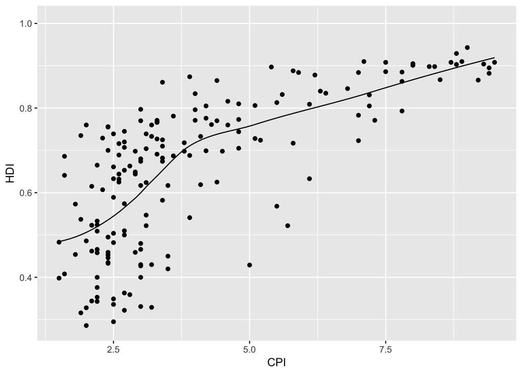

```r
ggplot(dat, aes(x = CPI, y = HDI)) +
    geom_point() +
    geom_line(stat = "smooth", method = "loess")
```

3. Overlay a smoothing line on top of the scatter plot using the default `loess` method, but make it less smooth. Hint: see `?loess`.

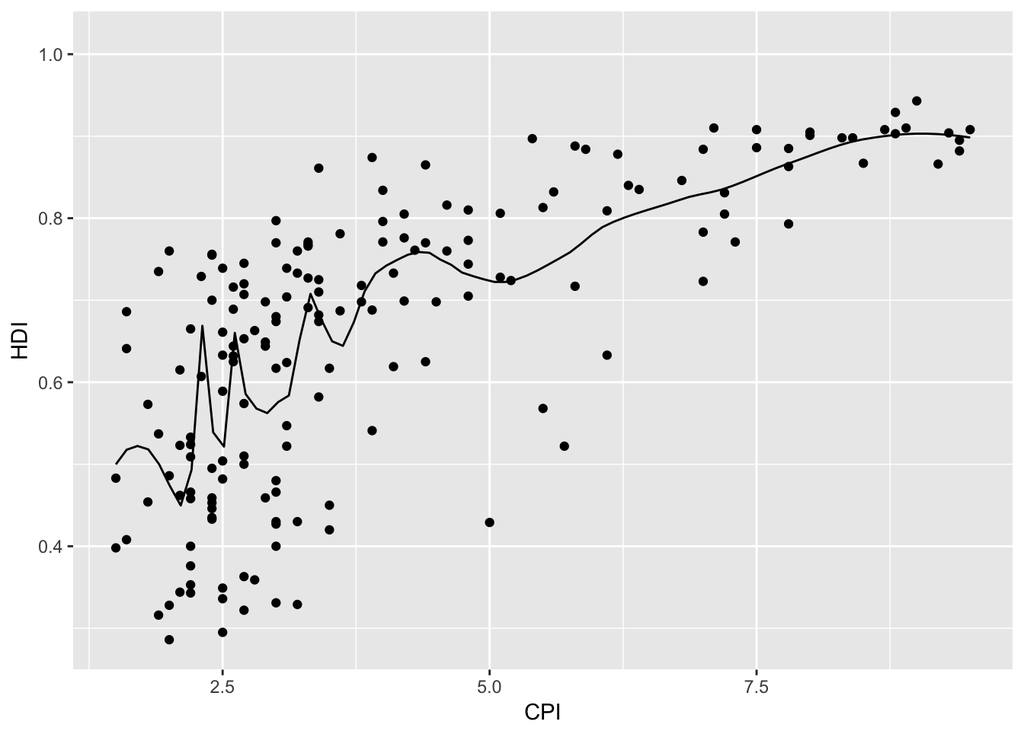

```r
ggplot(dat, aes(x = CPI, y = HDI)) +
    geom_point() +
    geom_line(stat = "smooth", method = "loess", span = 0.2)
```

4. Try the above, but with different colors and smoothing for each `Region`.

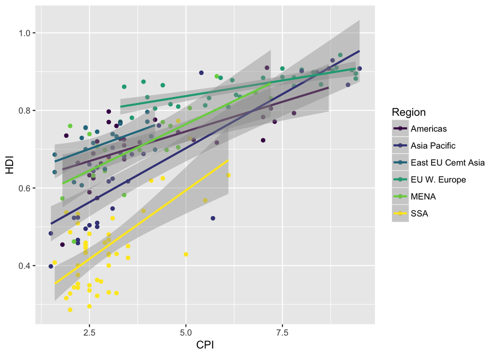

```r
ggplot(dat, aes(x = CPI, y = HDI,
                group = Region, color = Region)) +
    geom_point() +
    geom_smooth(method = "lm") +
    scale_color_viridis(discrete = TRUE)
```

# 7 Resources

- [theme layer documentation in ggplot -- http://docs.ggplot2.org/dev/vignettes/themes.html](http://docs.ggplot2.org/dev/vignettes/themes.html)
- [`spaceMovie` package for Star Wars palettes -- https://github.com/butterflyology/spaceMovie](https://github.com/butterflyology/spaceMovie)
- [`viridis` package for color palettes -- https://cran.r-project.org/web/packages/viridis/vignettes/intro-to-viridis.html](https://cran.r-project.org/web/packages/viridis/vignettes/intro-to-viridis.html)
- Info about different color scales in ggplot -- http://www.cookbook-r.com/Graphs/Colors_(ggplot2)/
- [Cheatsheet about color palettes -- https://www.nceas.ucsb.edu/~frazier/RSpatialGuides/colorPaletteCheatsheet.pdf](https://www.nceas.ucsb.edu/~frazier/RSpatialGuides/colorPaletteCheatsheet.pdf)